# MaxAsymetric

Maxwell Cornellier

12/3/2020

```r
library(data.table)
library(dplyr)
```

```r
library(ggplot2)
library(geosphere)
library(ggmap)
library(lubridate)
masterdata <- read.csv("new_MASTER_01_data.csv")
#sample_01_data <- read.csv("sample_01_data.csv")
#masterdata$newStartTime <- sample_01_data$starttime
#masterdata$newStopTime <- sample_01_data$stoptime
#write.csv(masterdata,"new_MASTER_01_data.csv")


#is the date data gone?
#summary(read.csv("sample_01_data.csv"))
#convert columns to factors as needed

masterdata$bikeid <- as.factor(masterdata$bikeid)
masterdata$gender <- as.factor(masterdata$gender)

masterdata$gender <- as.factor(ifelse(masterdata$gender == "0", "Unknown", ifelse(masterdata$gender == "1", "Male", "Female")))
masterdata$X <- NULL
masterdata$starttime <- NULL
masterdata$stoptime <- NULL

masterdata$newStartTime = as.POSIXct(strptime(masterdata$newStartTime, "%Y-%m-%d %H:%M:%S"))
masterdata$newStopTime = as.POSIXct(strptime(masterdata$newStopTime, "%Y-%m-%d %H:%M:%S"))

masterdata$newStartDate <- as.Date(masterdata$newStartTime)
masterdata$newStopDate <- as.Date(masterdata$newStopTime)


#distance
masterstart <- as.data.frame(matrix(nrow = 205517, ncol = 0))
masterstart$startlong <- as.numeric(masterdata$start.station.longitude)
masterstart$startlat <- as.numeric(masterdata$start.station.latitude)

masterend <- as.data.frame(matrix(nrow = 205517, ncol = 0))
masterend$endlong <- masterdata$end.station.longitude
masterend$endlat <- masterdata$end.station.latitude

masterdata$distanceH <- distHaversine(masterstart, masterend, r=6378137)

masterend <- NULL
masterstart <- NULL

masterdata$startMonth <- month(masterdata$newStartDate)
masterdata$stopMonth <- month(masterdata$newStopDate)
masterdata$startMonthFactor <- as.factor(month(masterdata$newStartDate))
masterdata$stopMonthFactor <- as.factor(month(masterdata$newStopDate))

#Create Time of Day Factor

masterdata$timeOfDay <- ifelse(hour(masterdata$newStartTime) >= 0 & hour(masterdata$newStartTime) < 12, "morning", ifelse(hour(masterdata$newStartTime) >= 12 & hour(masterdata$newStartTime) <=24, "afternoon","night"))


masterdata$timeOfDay <- as.factor(masterdata$timeOfDay)
#Day of Week

masterdata$numWeekday <- as.factor(wday(masterdata$newStartDate))


# Create data frame for AM and one for PM

masterAM <- filter(masterdata, masterdata$timeOfDay == "morning")
masterPM <- filter(masterdata,masterdata$timeOfDay == "afternoon")


# Create subsets for Weekday and Weekend
weekdayData <- subset(masterAM, subset = (masterAM$numWeekday != "7" & masterAM$numWeekday != "1"))
weekendData <- subset(masterAM, subset = (masterAM$numWeekday == "7" | masterAM$numWeekday == "1"))
```

# What Stations Gain or Lose Bikes throughout the day ?

```r
# Unique Departures and Arrivals for Each Citi Bike Station
StationStartsAM <- as.data.frame(table(masterAM$start.station.name))
StationEndsAM <- as.data.frame(table(masterAM$end.station.name))

StationDataAM <- data.frame(masterAM$start.station.name)
StationDataAM <- unique(StationDataAM)
StationDataAM$numStarts <- StationStartsAM$Freq[match(StationDataAM$masterAM.start.station.name, StationStartsAM$Var1)]
StationDataAM$numEnds <- StationEndsAM$Freq[match(StationDataAM$masterAM.start.station.name, StationEndsAM$Var1)]


# Compute the difference (Arrivals > Departures)
StationDataAM$difference <- StationDataAM$numEnds - StationDataAM$numStarts
StationDataAM <- arrange(StationDataAM, desc(difference))
StationDataAM <- na.omit(StationDataAM)

# Top 10 stations that gain bikes throughout the morning

TopTenSurplusAM <- head(StationDataAM, 10)


# Top 10 stations that lose bikes throughout the morning

TopTenDeficitAM <-tail(StationDataAM, 10)
TopTenDeficitAM <- arrange(TopTenDeficitAM, difference)


#Replicate for PM times


# Unique Departures and Arrivals for Each Citi Bike Station
StationStartsPM <- as.data.frame(table(masterPM$start.station.name))
StationEndsPM <- as.data.frame(table(masterPM$end.station.name))

StationDataPM <- data.frame(masterPM$start.station.name)
StationDataPM <- unique(StationDataPM)
StationDataPM$numStarts <- StationStartsPM$Freq[match(StationDataPM$masterPM.start.station.name, StationStartsPM$Var1)]
StationDataPM$numEnds <- StationEndsPM$Freq[match(StationDataPM$masterPM.start.station.name, StationEndsPM$Var1)]


# Compute the difference (Arrivals > Departures)
StationDataPM$difference <- StationDataPM$numEnds - StationDataPM$numStarts
StationDataPM <- arrange(StationDataPM, desc(difference))
StationDataPM <- na.omit(StationDataPM)

# Top 10 stations that gain bikes throughout the morning
TopTenSurplusPM <- head(StationDataPM, 10)

# Top 10 stations that lose bikes throughout the morning

TopTenDeficitPM <-tail(StationDataPM, 10)
TopTenDeficitPM <- arrange(TopTenDeficitPM, difference)


TopTenSurplusAM
```

```
##          masterAM.start.station.name numStarts numEnds difference
## 1                 Broadway & E 22 St       239     623        384
## 2      North Moore St & Greenwich St       108     485        377
## 3                 E 47 St & Park Ave       242     582        340
## 4                    W 52 St & 6 Ave       156     439        283
## 5                    W 52 St & 5 Ave        77     355        278
## 6                   6 Ave & Canal St        89     364        275
## 7  Grand Army Plaza & Central Park S       169     423        254
## 8               E 24 St & Park Ave S       252     472        220
## 9                    E 48 St & 5 Ave       153     356        203
## 10             Broadway & Battery Pl        91     288        197
```

```r
TopTenDeficitAM
```

```
##      masterAM.start.station.name numStarts numEnds difference
## 1                8 Ave & W 31 St       709     260       -449
## 2             E 13 St & Avenue A       386     125       -261
## 3             E 10 St & Avenue A       353     108       -245
## 4  Christopher St & Greenwich St       449     270       -179
## 5               12 Ave & W 40 St       404     233       -171
## 6              E 6 St & Avenue B       269      98       -171
## 7                1 Ave & E 18 St       272     103       -169
## 8              E 7 St & Avenue A       311     142       -169
## 9              E 2 St & Avenue B       266     100       -166
## 10           E 20 St & FDR Drive       260      96       -164
```

```r
TopTenSurplusPM
```

```
##    masterPM.start.station.name numStarts numEnds difference
## 1              8 Ave & W 31 St       491     909        418
## 2           E 10 St & Avenue A       342     607        265
## 3          E 20 St & FDR Drive       262     450        188
## 4            E 2 St & Avenue B       281     465        184
## 5           E 13 St & Avenue A       464     639        175
## 6            E 6 St & Avenue B       284     454        170
## 7              1 Ave & E 16 St       494     655        161
## 8          St Marks Pl & 1 Ave       383     541        158
## 9             12 Ave & W 40 St       610     761        151
## 10             1 Ave & E 18 St       297     445        148
```

```r
TopTenDeficitPM
```

```
##          masterPM.start.station.name numStarts numEnds difference
## 1      North Moore St & Greenwich St       611     258       -353
## 2  Grand Army Plaza & Central Park S       636     311       -325
## 3                 Broadway & E 22 St       886     571       -315
## 4                 E 47 St & Park Ave       515     223       -292
## 5                    W 52 St & 5 Ave       441     191       -250
## 6                    W 52 St & 6 Ave       432     195       -237
## 7                    E 48 St & 5 Ave       513     280       -233
## 8               E 24 St & Park Ave S       607     391       -216
## 9                   6 Ave & Canal St       394     191       -203
## 10             Broadway & Battery Pl       372     210       -162
```

## Visualize Top Tens

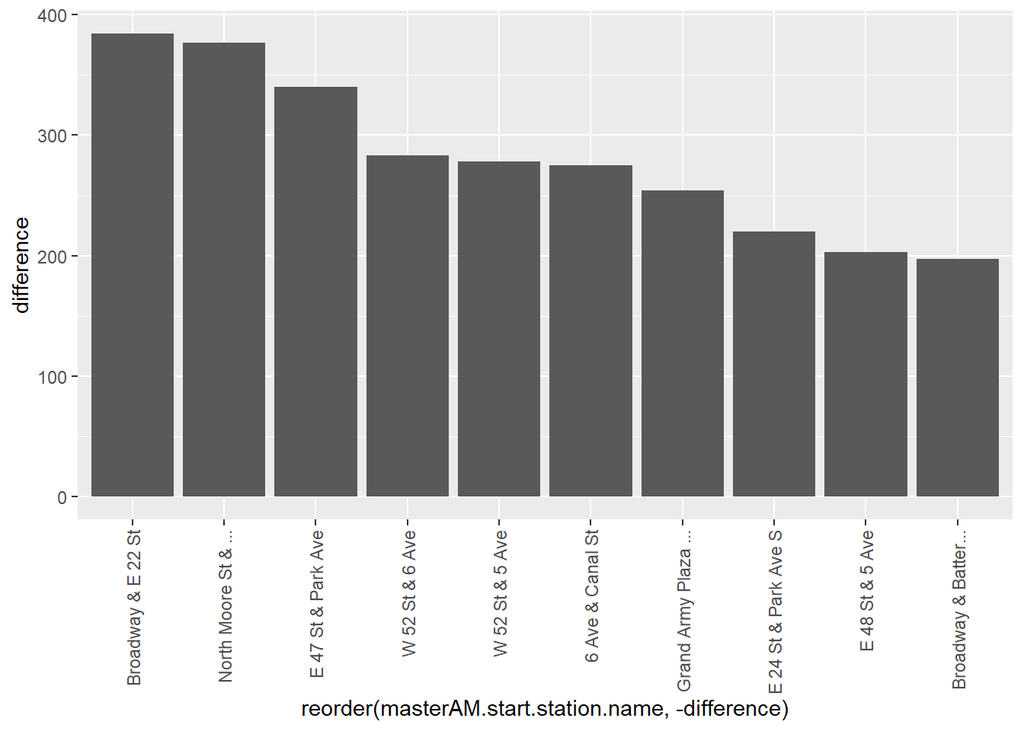

```r
# Top Ten gains in the morning

TenSurplusMorning <- ggplot(TopTenSurplusAM, aes(reorder(masterAM.start.station.name, - difference), difference)) +
    geom_col() +
    scale_x_discrete(label = function(x) stringr::str_trunc(x, 20)) +
    theme(axis.text.x = element_text(angle = 90, hjust = 1, vjust = 0.5))
TenSurplusMorning
```

Analysis: this chart shows a high level of asymmetry among the bike stations with station “Broadwat & E 22 St” having 384 more arrivals than departures in the morning throughout the year.

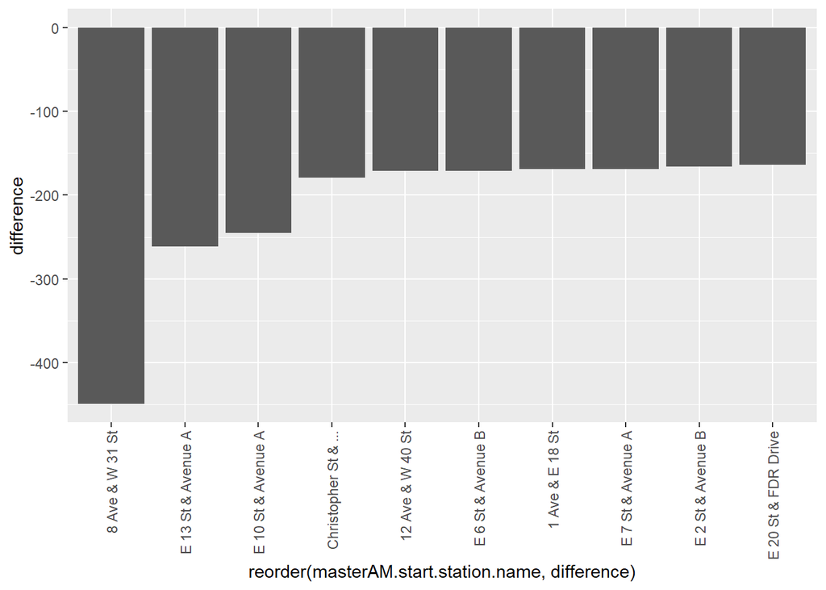

```r
# Top Ten loses in the morning
TenDeficitMorning <- ggplot(TopTenDeficitAM, aes(reorder(masterAM.start.station.name,  difference), difference)) +
    geom_col() +
    scale_x_discrete(label = function(x) stringr::str_trunc(x, 20)) +
    theme(axis.text.x = element_text(angle = 90, hjust = 1, vjust = 0.5))
TenDeficitMorning
```

Analysis: Asymmetric traffic patterns are also evident in the chart above, with station “8 Ave & W 31 St” experiencing 449 more departures than arrivals in the morning throughout the year.

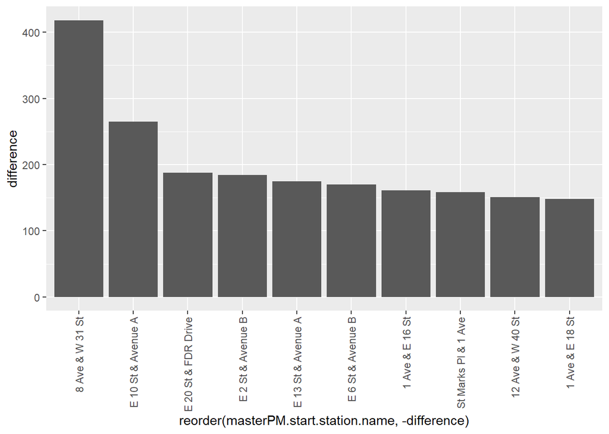

```r
# Top Ten gains in the afternoon

TenSurplusAfternoon<- ggplot(TopTenSurplusPM, aes(reorder(masterPM.start.station.name, - difference), difference)) +
    geom_col() +
    scale_x_discrete(label = function(x) stringr::str_trunc(x, 20)) +
    theme(axis.text.x = element_text(angle = 90, hjust = 1, vjust = 0.5))
TenSurplusAfternoon
```

Analysis: The evidence of asymmetric traffic is also present in this chart, with station " 8 Ave & W 31 St " leading with 418 more arrivals than departures. Some symmetry between the two time periods is seen here with a loss of 449 bikes at this same station in the morning time period throughout the year. In fact, 8 of the top 10 stations that lose bikes in the morning period are present here gaining bikes.

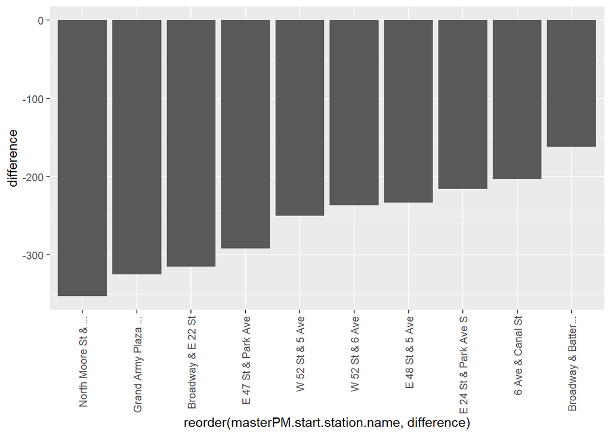

```r
# Top Ten loses in the afternoon

TenDeficitAfternoon <- ggplot(TopTenDeficitPM, aes(reorder(masterPM.start.station.name,  difference), difference)) +
    geom_col() +
    scale_x_discrete(label = function(x) stringr::str_trunc(x, 20)) +
    theme(axis.text.x = element_text(angle = 90, hjust = 1, vjust = 0.5))
TenDeficitAfternoon
```

Analysis:

In the chart for the top ten stations that experience losses all ten of the stations that experience overflow of bikes in the morning time perion are present here.

## Does Weekend vs. Weekday have an effect on asymmetric traffic? Test Hypothesis that asymmetry is due to work commutes

For this I compared weekdays vs . weekends for data from the first 12 hours of the data (masterAM)

```r
#create counts of data
# Unique Departures and Arrivals for Each Citi Bike Station for Week
StationStartsWeek <- as.data.frame(table(weekdayData$start.station.name))
StationEndsWeek <- as.data.frame(table(weekdayData$end.station.name))

StationDataWeek <- data.frame(weekdayData$start.station.name)
StationDataWeek <- unique(StationDataWeek)
StationDataWeek$numStarts <- StationStartsWeek$Freq[match(StationDataWeek$weekdayData.start.station.name, StationStartsWeek$Var1)]
StationDataWeek$numEnds <- StationEndsWeek$Freq[match(StationDataWeek$weekdayData.start.station.name, StationEndsWeek$Var1)]


# Compute the difference (Arrivals > Departures)
StationDataWeek$difference <- StationDataWeek$numEnds - StationDataWeek$numStarts
StationDataWeek <- arrange(StationDataWeek, desc(difference))
StationDataWeek <- na.omit(StationDataWeek)

# Top 10 stations that gain bikes throughout Weekdays

TopTenSurplusWeek <- head(StationDataWeek, 10)


# Top 10 stations that lose bikes throughout Weekend Mornings

TopTenDeficitWeek <-tail(StationDataWeek, 10)
TopTenDeficitWeek <- arrange(TopTenDeficitWeek, difference)


#create counts of data
# Unique Departures and Arrivals for Each Citi Bike Station for Weekend
StationStartsWeekend <- as.data.frame(table(weekendData$start.station.name))
StationEndsWeekend <- as.data.frame(table(weekendData$end.station.name))

StationDataWeekend <- data.frame(weekendData$start.station.name)
StationDataWeekend <- unique(StationDataWeekend)
StationDataWeekend$numStarts <- StationStartsWeekend$Freq[match(StationDataWeekend$weekendData.start.station.name, StationStartsWeekend$Var1)]
StationDataWeekend$numEnds <- StationEndsWeekend$Freq[match(StationDataWeekend$weekendData.start.station.name, StationEndsWeekend$Var1)]


# Compute the difference (Arrivals > Departures)
StationDataWeekend$difference <- StationDataWeekend$numEnds - StationDataWeekend$numStarts
StationDataWeekend <- arrange(StationDataWeekend, desc(difference))
StationDataWeekend <- na.omit(StationDataWeekend)

# Top 10 stations that gain bikes throughout Weekend Mornings

TopTenSurplusWeekend <- head(StationDataWeekend, 10)


# Top 10 stations that lose bikes throughout Weekend Mornings

TopTenDeficitWeekend <-tail(StationDataWeekend, 10)
TopTenDeficitWeekend <- arrange(TopTenDeficitWeekend, difference)
```

## Top Surplus During Week Mornings

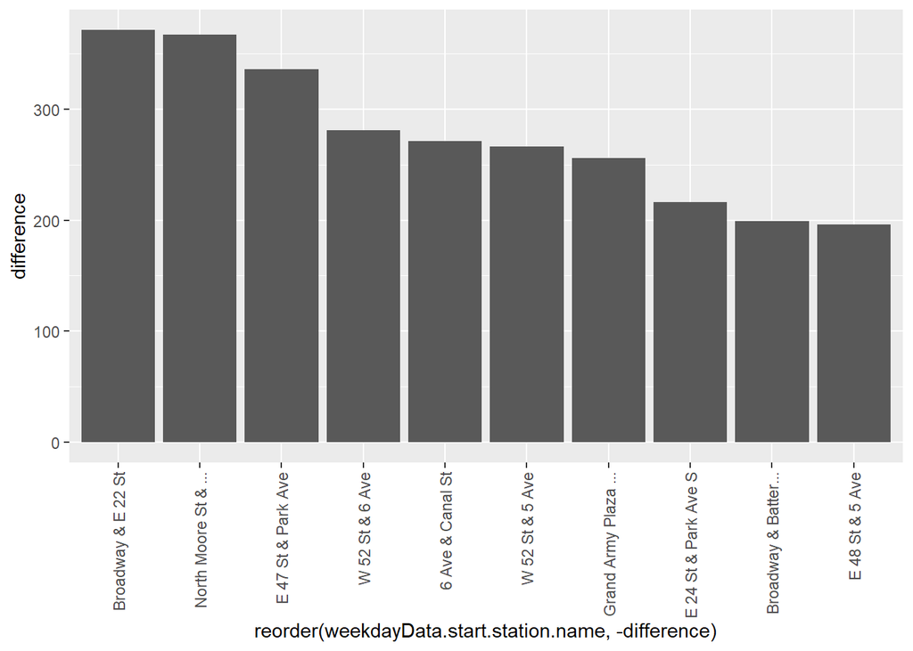

```r
TenSurplusWeek <- ggplot(TopTenSurplusWeek, aes(reorder(weekdayData.start.station.name, - difference), difference)) +
    geom_col() +
    scale_x_discrete(label = function(x) stringr::str_trunc(x, 20)) +
    theme(axis.text.x = element_text(angle = 90, hjust = 1, vjust = 0.5))
TenSurplusWeek
```

## Top Deficit during Week Mornings

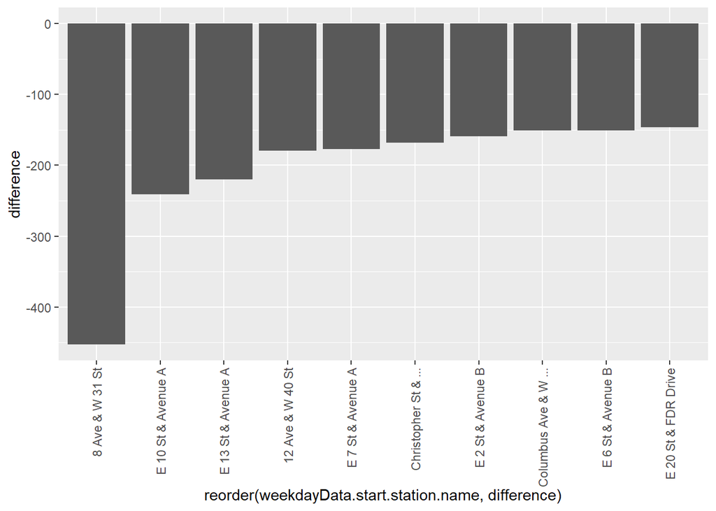

```r
TenDeficitWeek <- ggplot(TopTenDeficitWeek, aes(reorder(weekdayData.start.station.name,  difference), difference)) +
    geom_col() +
    scale_x_discrete(label = function(x) stringr::str_trunc(x, 20)) +
    theme(axis.text.x = element_text(angle = 90, hjust = 1, vjust = 0.5))
TenDeficitWeek
```

### Top Surplus During Weekend Mornings

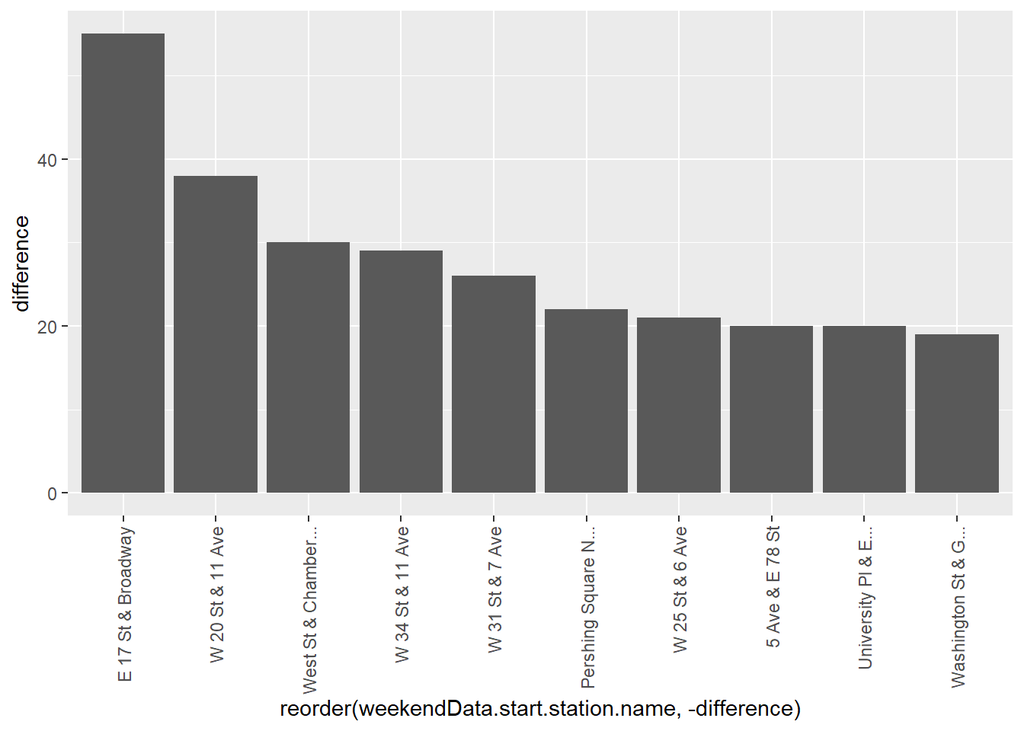

```r
TenSurplusWeekend <- ggplot(TopTenSurplusWeekend, aes(reorder(weekendData.start.station.name, - difference), difference)) +
    geom_col() +
    scale_x_discrete(label = function(x) stringr::str_trunc(x, 20)) +
    theme(axis.text.x = element_text(angle = 90, hjust = 1, vjust = 0.5))
TenSurplusWeekend
```

## Top Deficit during Weekend Mornings

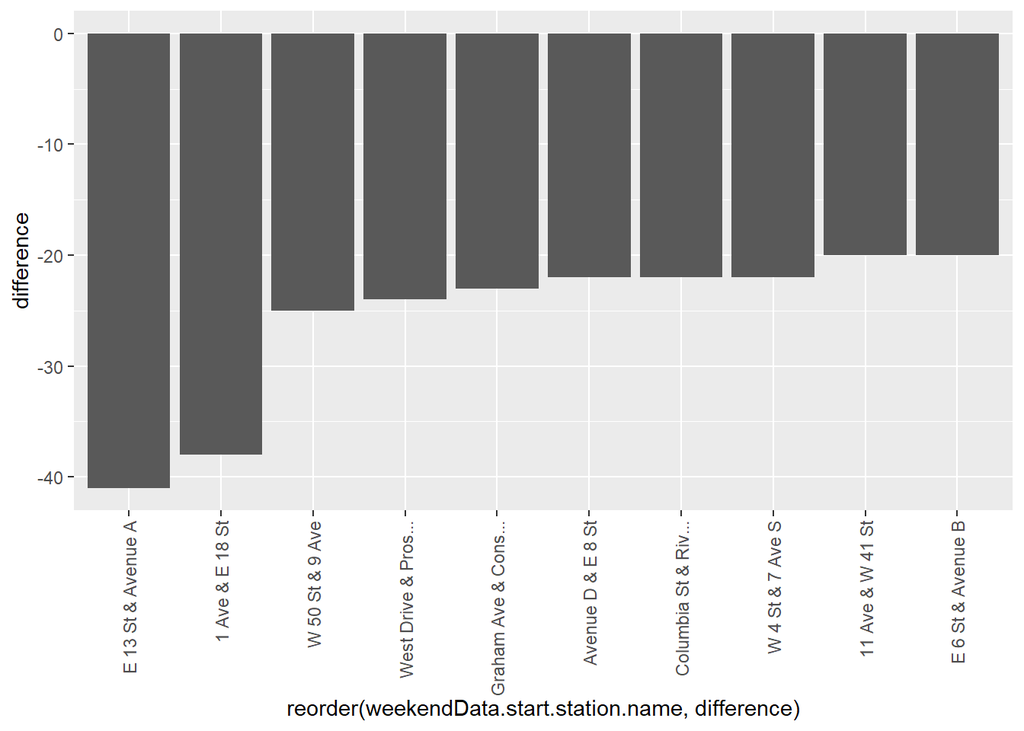

```r
TenDeficitWeekend <- ggplot(TopTenDeficitWeekend, aes(reorder(weekendData.start.station.name,  difference), difference)) +
    geom_col() +
    scale_x_discrete(label = function(x) stringr::str_trunc(x, 20)) +
    theme(axis.text.x = element_text(angle = 90, hjust = 1, vjust = 0.5))
TenDeficitWeekend
```

## What user types are using these top asymmetric stations?

```r
CountCustomerBroadway <- nrow(masterAM[masterAM$usertype == "Customer" & masterAM$start.station.name == "Broadway & E 22 St",])
CountSubscriberBroadway <- nrow(masterAM[masterAM$usertype == "Subscriber" & masterAM$start.station.name == "Broadway & E 22 St",])
CountCustomerNMoore <- nrow(masterPM[masterPM$usertype == "Customer" & masterPM$start.station.name == "North Moore St & Greenwich St",])
CountSubscriberNMoore <- nrow(masterPM[masterPM$usertype == "Subscriber" & masterPM$start.station.name == "North Moore St & Greenwich St",])
```

Analysis: For stations that are asymmetric, users tend to be “subscribers” as opposed to “customers”. At the station “Broadway & E 22 St” of the 239 users who started trips there 230 are subscribers while only 9. For another station “North Moore St & Greenwich” there was only 61customers while there was 550 Subscribers.

#Map

```r
# Add longitude and latitude to the dataset

startlatitude <- c(40.7403432,40.72019521,40.75510267, 40.76132983,40.75992262,40.72243797,40.7643971,40.74096374, 40.75724568, 40.70463334)

TopTenSurplusAM$startlatitude <- startlatitude

startlongitude <- c(-73.98955109,-74.01030064,-73.97498696
,-73.97982001, -73.97648516, -74.00566443
, -73.97371465, -73.98602213, -73.97805914
, -74.01361706)

TopTenSurplusAM$startlongitude <- startlongitude
```

##Map Showing top ten surplus AM

[figure not shown]

```r
#Map TopTenSurplus AM


register_google(key = "AIzaSyDr6TG5wIRo6iXXvRbE0rV3n2EPx1jApRc")

## get station info
station.info <- TopTenSurplusAM %>%
  group_by(masterAM.start.station.name) %>%
  summarise(lat=as.numeric(startlatitude),
            long=as.numeric(startlongitude),
            difference = difference)
## get map and plot station locations
newyork.map <- get_map(location= 'Lower Manhattan, New York',
                       maptype='roadmap', color='bw',source='google',zoom=12)
ggmap(newyork.map) +
  geom_point(data=station.info,aes(x=long,y=lat,color= difference),size=5,alpha=0.75)+
  scale_colour_gradient(high="red",low='green')+
  theme(axis.ticks = element_blank(),axis.text = element_blank())+
  xlab('')+ylab('')
```